# Analyzing Mental Health Disorder Prevalence in the United States

## Introduction

In recent years, we have seen a paradigm shift in how we consider mental health as a part of our daily lives. While it remains shrouded in [social stigma](https://www.psychiatry.org/patients-families/stigma-and-discrimination) to some extent, professionals in the healthcare field have long since reached a strong consensus that indeed, [mental health is important to our well-being](https://www.cdc.gov/mentalhealth/learn/index.htm). In many ways, it can influence our [physical health](https://www.cdc.gov/diabetes/managing/mental-health.html), further driving the fact that it must remain a top priority to our well-being.

Of the many mental health disorders, two stand out as some of the most well-known: [anxiety and depression](https://www.cdc.gov/tobacco/campaign/tips/diseases/depression-anxiety.html). Both are uniquely defined yet comorbid with one another. In any case, given that they both interrupt an individual's ability to function properly, it remains an important topic to address in today's world.

As such, in this tutorial, we will analyze how prevalent anxiety and depression are in the United States. In doing so, we can begin to answer various questions: What are the most susceptible demographics to anxiety or depression? How do various states compare? Has there been a noticeable increase or decrease over time?

# Data Collection

The dataset we will be using in this tutorial comes from the [Household Pulse Survey](https://data.cdc.gov/NCHS/Indicators-of-Anxiety-or-Depression-Based-on-Repor/8pt5-q6wp), a collaborative effort from the National Center for Health Statistics and five other federal agencies. This dataset is updated frequently, with results ranging from as early as April 23, 2020, to November 14, 2022. With this in mind, if you are following this tutorial in the far-off future, you may be able to draw new insights as this dataset gets updated over time!

To begin, we will need to import some Python packages that will help us during our data analysis. In particular:

- [pandas](https://pandas.pydata.org/pandas-docs/stable/)
- [numpy](https://docs.scipy.org/doc/numpy/user/quickstart.html)
- [folium](https://python-visualization.github.io/folium/)
- [matplotlib](https://matplotlib.org/stable/index.html)
- [datetime](https://docs.python.org/3/library/datetime.html)
- [requests](https://docs.python-requests.org/en/latest/)
- [BeautifulSoup](https://beautiful-soup-4.readthedocs.io/en/latest/)
- [re](https://docs.python.org/3/library/re.html)

First, we should take a look at our dataset to get a sense of what exactly we will be working with.

```python
import pandas as pd
import numpy as np
import folium
import matplotlib.pyplot as plt
import matplotlib.dates as mdates
import datetime as dt
import folium.plugins as plugins
from folium.plugins import HeatMap, MarkerCluster, HeatMapWithTime
import requests
from bs4 import BeautifulSoup
import re
df_all_indicators = pd.read_csv("Indicators_of_Anxiety_or_Depression_Based_on_Reported_Frequency_of_Symptoms_During_Last_7_Days.csv")
print(df_all_indicators['Indicator'].unique())
df_all_indicators
```

```
['Symptoms of Depressive Disorder' 'Symptoms of Anxiety Disorder'
 'Symptoms of Anxiety Disorder or Depressive Disorder']
```

|  | Indicator | Group | State | Subgroup | Phase | Time Period | Time Period Label | Time Period Start Date | Time Period End Date | Value | Low CI | High CI | Confidence Interval | Quartile Range |
| --- | --- | --- | --- | --- | --- | --- | --- | --- | --- | --- | --- | --- | --- | --- |
| 0 | Symptoms of Depressive Disorder | National Estimate | United States | United States | 1 | 1 | Apr 23 - May 5, 2020 | 04/23/2020 | 05/05/2020 | 23.5 | 22.7 | 24.3 | 22.7 - 24.3 | NaN |
| 1 | Symptoms of Depressive Disorder | By Age | United States | 18 - 29 years | 1 | 1 | Apr 23 - May 5, 2020 | 04/23/2020 | 05/05/2020 | 32.7 | 30.2 | 35.2 | 30.2 - 35.2 | NaN |
| 2 | Symptoms of Depressive Disorder | By Age | United States | 30 - 39 years | 1 | 1 | Apr 23 - May 5, 2020 | 04/23/2020 | 05/05/2020 | 25.7 | 24.1 | 27.3 | 24.1 - 27.3 | NaN |
| 3 | Symptoms of Depressive Disorder | By Age | United States | 40 - 49 years | 1 | 1 | Apr 23 - May 5, 2020 | 04/23/2020 | 05/05/2020 | 24.8 | 23.3 | 26.2 | 23.3 - 26.2 | NaN |
| 4 | Symptoms of Depressive Disorder | By Age | United States | 50 - 59 years | 1 | 1 | Apr 23 - May 5, 2020 | 04/23/2020 | 05/05/2020 | 23.2 | 21.5 | 25.0 | 21.5 - 25.0 | NaN |
| ... | ... | ... | ... | ... | ... | ... | ... | ... | ... | ... | ... | ... | ... | ... |
| 11713 | Symptoms of Anxiety Disorder or Depressive Dis... | By State | Virginia | Virginia | 3.6 | 51 | Nov 2 - Nov 14, 2022 | 11/02/2022 | 11/14/2022 | 32.1 | 28.3 | 36.1 | 28.3 - 36.1 | 25.6-32.9 |
| 11714 | Symptoms of Anxiety Disorder or Depressive Dis... | By State | Washington | Washington | 3.6 | 51 | Nov 2 - Nov 14, 2022 | 11/02/2022 | 11/14/2022 | 33.3 | 30.9 | 35.9 | 30.9 - 35.9 | 33.0-35.2 |
| 11715 | Symptoms of Anxiety Disorder or Depressive Dis... | By State | West Virginia | West Virginia | 3.6 | 51 | Nov 2 - Nov 14, 2022 | 11/02/2022 | 11/14/2022 | 37.2 | 32.0 | 42.5 | 32.0 - 42.5 | 35.3-37.2 |
| 11716 | Symptoms of Anxiety Disorder or Depressive Dis... | By State | Wisconsin | Wisconsin | 3.6 | 51 | Nov 2 - Nov 14, 2022 | 11/02/2022 | 11/14/2022 | 30.5 | 27.0 | 34.2 | 27.0 - 34.2 | 25.6-32.9 |
| 11717 | Symptoms of Anxiety Disorder or Depressive Dis... | By State | Wyoming | Wyoming | 3.6 | 51 | Nov 2 - Nov 14, 2022 | 11/02/2022 | 11/14/2022 | 35.6 | 31.1 | 40.4 | 31.1 - 40.4 | 35.3-37.2 |

11718 rows × 14 columns

Okay! We have our dataset all ready for us to use. But what exactly are we working with? What does each row and column represent?

- `Indicator`: Symptom(s) surveyed. May be anxiety, depression, or whether a participant has at least one.
- `Group`: The survey's intended focus group/audience. They may group by age, state, race/ethnicity, etc.
- `State`: The state of focus. "United States" may also be marked here for a survey of the whole country.
- `Subgroup`: A narrower group within the existing `Group` category. For example, if we group by education, we may only want to view those who have a high school level education.
- `Phase`: A time period in which the survey was conducted, spanning various `Time Period` groups.
- `Time Period`: A purely numerical way to index the `Time Period Label` column.
- `Time Period Label`: A description of when survey data was collected.
- `Time Period Start Data`: The start date of when a survey was conducted.
- `Time Period End Data`: The end date of when a survey was conducted.
- `Value`: The percentage of participants who indicated positive for the `Indicator`.
- `Low CI`: Low confidence interval.
- `High CI`: High confidence interval.
- `Confidence Interval`: The range of values that, if the study was performed again, may fall into.
- `Quartile Range`: Range of data divisions.

# Data Management

For this tutorial's purposes, we will not need columns that deal with phases, confidence intervals, and quartile ranges. We can also remove redundant columns, such as `Time Period Label`. We should also ensure that any missing data is removed.

Also, since we're analyzing mental health as a whole rather than just one disorder, we should just pull our data from rows that have a `Symptoms of Anxiety Disorder or Depressive Disorder` indicator!

```python
df_all_indicators.drop(['Phase', 'Time Period Label', 'Low CI', 'High CI', 'Confidence Interval', 'Quartile Range'], axis=1, inplace=True)
df_either = df_all_indicators.copy(deep=True)
df_either = df_either[(df_either["Indicator"] == 'Symptoms of Anxiety Disorder or Depressive Disorder')]
df_either = df_either.dropna()
df_either
```

|  | Indicator | Group | State | Subgroup | Time Period | Time Period Start Date | Time Period End Date | Value |
| --- | --- | --- | --- | --- | --- | --- | --- | --- |
| 140 | Symptoms of Anxiety Disorder or Depressive Dis... | National Estimate | United States | United States | 1 | 04/23/2020 | 05/05/2020 | 35.9 |
| 141 | Symptoms of Anxiety Disorder or Depressive Dis... | By Age | United States | 18 - 29 years | 1 | 04/23/2020 | 05/05/2020 | 46.8 |
| 142 | Symptoms of Anxiety Disorder or Depressive Dis... | By Age | United States | 30 - 39 years | 1 | 04/23/2020 | 05/05/2020 | 39.6 |
| 143 | Symptoms of Anxiety Disorder or Depressive Dis... | By Age | United States | 40 - 49 years | 1 | 04/23/2020 | 05/05/2020 | 38.9 |
| 144 | Symptoms of Anxiety Disorder or Depressive Dis... | By Age | United States | 50 - 59 years | 1 | 04/23/2020 | 05/05/2020 | 35.8 |
| ... | ... | ... | ... | ... | ... | ... | ... | ... |
| 11713 | Symptoms of Anxiety Disorder or Depressive Dis... | By State | Virginia | Virginia | 51 | 11/02/2022 | 11/14/2022 | 32.1 |
| 11714 | Symptoms of Anxiety Disorder or Depressive Dis... | By State | Washington | Washington | 51 | 11/02/2022 | 11/14/2022 | 33.3 |
| 11715 | Symptoms of Anxiety Disorder or Depressive Dis... | By State | West Virginia | West Virginia | 51 | 11/02/2022 | 11/14/2022 | 37.2 |
| 11716 | Symptoms of Anxiety Disorder or Depressive Dis... | By State | Wisconsin | Wisconsin | 51 | 11/02/2022 | 11/14/2022 | 30.5 |
| 11717 | Symptoms of Anxiety Disorder or Depressive Dis... | By State | Wyoming | Wyoming | 51 | 11/02/2022 | 11/14/2022 | 35.6 |

3726 rows × 8 columns

Looks good! But we can also get rid of our `Indicator` column since we filtered our dataset to only have one possible indicator.

```python
df_either.drop(['Indicator'], axis=1, inplace=True)
df_either.head()
```

|  | Group | State | Subgroup | Time Period | Time Period Start Date | Time Period End Date | Value |
| --- | --- | --- | --- | --- | --- | --- | --- |
| 140 | National Estimate | United States | United States | 1 | 04/23/2020 | 05/05/2020 | 35.9 |
| 141 | By Age | United States | 18 - 29 years | 1 | 04/23/2020 | 05/05/2020 | 46.8 |
| 142 | By Age | United States | 30 - 39 years | 1 | 04/23/2020 | 05/05/2020 | 39.6 |
| 143 | By Age | United States | 40 - 49 years | 1 | 04/23/2020 | 05/05/2020 | 38.9 |
| 144 | By Age | United States | 50 - 59 years | 1 | 04/23/2020 | 05/05/2020 | 35.8 |

To draw conclusions about our data, we first have to understand what we are working with. What do our groups and subgroups look like?

```python
def get_groups_and_subgroups(print_flag, return_flag):
    subgroup_dict = {}
    for group,idx in df_either.groupby("Group"):
        subgroup_arr = []
        if(print_flag):
            print("GROUP \"" + str(group) + "\" has " + str(len(idx)) + " rows with the following subgroups...")
        for i in idx['Subgroup'].unique():
            if(print_flag):
                print("\t" + str(i))
            subgroup_arr.append(str(i))
        subgroup_dict[str(group)] = tuple(subgroup_arr) # Because lists can't a key in a dictionary in Python, we do something sneaky with a tuple.
    if(return_flag):
        return subgroup_dict
    else:
        return

get_groups_and_subgroups(print_flag=True, return_flag=False) # Ignore the result, we don't want a dictionary of our groups and subgroups just yet.
```

```
GROUP "By Age" has 357 rows with the following subgroups...
	18 - 29 years
	30 - 39 years
	40 - 49 years
	50 - 59 years
	60 - 69 years
	70 - 79 years
	80 years and above
GROUP "By Disability status" has 48 rows with the following subgroups...
	With disability
	Without disability
GROUP "By Education" has 204 rows with the following subgroups...
	Less than a high school diploma
	High school diploma or GED
	Some college/Associate's degree
	Bachelor's degree or higher
GROUP "By Gender identity" has 54 rows with the following subgroups...
	Cis-gender male
	Cis-gender female
	Transgender
GROUP "By Race/Hispanic ethnicity" has 255 rows with the following subgroups...
	Hispanic or Latino
	Non-Hispanic White, single race
	Non-Hispanic Black, single race
	Non-Hispanic Asian, single race
	Non-Hispanic, other races and multiple races
GROUP "By Sex" has 102 rows with the following subgroups...
	Male
	Female
GROUP "By Sexual orientation" has 54 rows with the following subgroups...
	Gay or lesbian
	Straight
	Bisexual
GROUP "By State" has 2601 rows with the following subgroups...
	Alabama
	Alaska
	Arizona
	Arkansas
	California
	Colorado
```

[output cut: 32 more lines]

```
	Pennsylvania
	Rhode Island
	South Carolina
	South Dakota
	Tennessee
	Texas
	Utah
	Vermont
	Virginia
	Washington
	West Virginia
	Wisconsin
	Wyoming
GROUP "National Estimate" has 51 rows with the following subgroups...
	United States
```

Looks like we have quite a bit to parse through. Before analyzing our data, we should probably clear up one little discrepancy: the `National Estimate` group. It seems pointless to keep it alone with one subgroup, so we should put it in the `By State` group to better compare how the U.S. performs versus its states.

```python
df_either["Group"] = df_either["Group"].apply(lambda x: "By State" if x == "National Estimate" else x)
subgroup_dict = get_groups_and_subgroups(print_flag=False, return_flag=True)
df_either["Group"].unique()
```

```
array(['By State', 'By Age', 'By Sex', 'By Race/Hispanic ethnicity',
       'By Education', 'By Disability status', 'By Gender identity',
       'By Sexual orientation'], dtype=object)
```

Much better! Now we're ready to investigate our dataset.

# Exploratory Data Analysis

Let's first gather some basic data about each of our subgroups and groups. In particular, finding the count, mean, median, and standard deviation of each subgroup can help us see some trends in our dataset.

```python
def get_statistic_of_subgroup(df, subgroup, function):
    arr = []
    # Go through each row that matches the subgroup we're looking for.
    for idx,row in df[df['Subgroup']==subgroup].iterrows():
        # We want to apply some function to our subgroup's Value data, so we add it to a temporary list.
        arr.append(row['Value'])
    # Apply the function parameter to our array!
    return function(arr)

for group in subgroup_dict:
    subgroup_arr = list(subgroup_dict[group])
    print("=== Statistics " + group + " ===")
    for subgroup in subgroup_arr:
        print("\t -- SUBGROUP: " + subgroup + " --")
        print("\t\tCount: " + str(get_statistic_of_subgroup(df_either, subgroup, len)))
        print("\t\tMean: " + str(get_statistic_of_subgroup(df_either, subgroup, np.mean)))
        print("\t\tMedian: " + str(get_statistic_of_subgroup(df_either, subgroup, np.median)))
        print("\t\tMax: " + str(get_statistic_of_subgroup(df_either, subgroup, np.max)))
        print("\t\tStandard Deviation: " + str(get_statistic_of_subgroup(df_either, subgroup, np.std)))
    print("\n")
```

```
=== Statistics By Age ===
	 -- SUBGROUP: 18 - 29 years --
		Count: 51
		Mean: 50.04901960784313
		Median: 49.3
		Max: 58.7
		Standard Deviation: 3.6926196954603663
	 -- SUBGROUP: 30 - 39 years --
		Count: 51
		Mean: 41.601960784313725
		Median: 40.7
		Max: 49.5
		Standard Deviation: 3.4952343014441167
	 -- SUBGROUP: 40 - 49 years --
		Count: 51
		Mean: 37.40196078431372
		Median: 37.6
		Max: 45.6
		Standard Deviation: 3.6802328462182525
	 -- SUBGROUP: 50 - 59 years --
		Count: 51
		Mean: 33.719607843137254
		Median: 34.1
		Max: 41.3
		Standard Deviation: 4.163238728316944
	 -- SUBGROUP: 60 - 69 years --
		Count: 51
		Mean: 26.635294117647057
		Median: 27.3
		Max: 34.2
		Standard Deviation: 4.2835217107922015
	 -- SUBGROUP: 70 - 79 years --
		Count: 51
		Mean: 19.9921568627451
		Median: 19.5
		Max: 28.6
		Standard Deviation: 4.066401942713952
	 -- SUBGROUP: 80 years and above --
		Count: 51
		Mean: 18.470588235294116
```

[output cut: 435 more lines]

```
		Median: 37.9
		Max: 49.7
		Standard Deviation: 4.459384826794911
	 -- SUBGROUP: Wisconsin --
		Count: 51
		Mean: 29.939215686274512
		Median: 29.1
		Max: 40.0
		Standard Deviation: 4.32267520795623
	 -- SUBGROUP: Wyoming --
		Count: 51
		Mean: 32.370588235294115
		Median: 32.4
		Max: 44.8
		Standard Deviation: 4.625390036236141
```

We have our first insights into our dataset!

Taking a closer look, we can observe a few noticeable trends:

- Age seems to play a significant role, as it appears that the younger someone is, the higher likelihood they are of having anxiety or depressive disorder symptoms.
- Disability status, sexual orientation, and gender identity each have one clear subgroup that shows the most symptoms on average, along with higher maximums.
- Education does not have a clear trend as Age does since on average, people of the `Some college/Associate's Degree` subgroup showed more symptoms than those of `High school diploma or GED`.
- It is currently unclear whether the `Non-Hispanic, other races and multiple races` subgroup shows the most symptoms as a result of including several races or simply by demographics.

## Data Visualization of all Groups

While this basic data helps identify some trends across those who may suffer from anxiety or depression, it is rather surface-level and difficult to take in all of this information at once. Specifically, the `By State` subgroup suffers the most from information overload—we have *fifty* states to weigh, along with a national estimate!

To better compare our subgroups, let's visualize the averages of our values with bar plots!

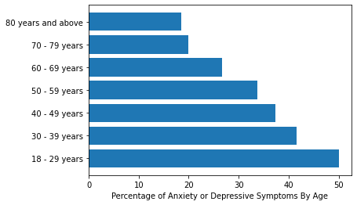

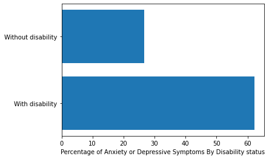

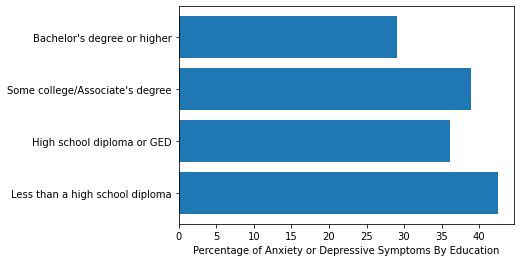

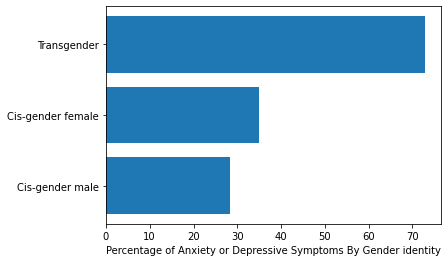

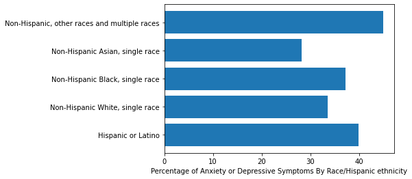

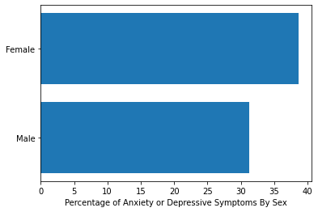

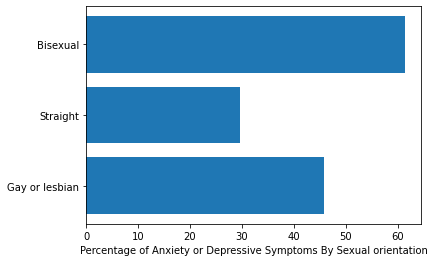

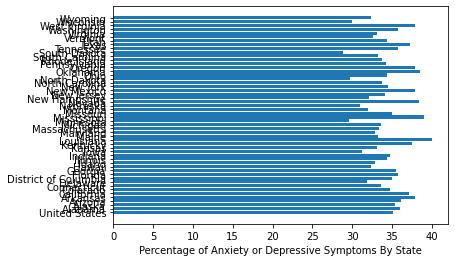

```python
for group in subgroup_dict:
    subgroup_arr = list(subgroup_dict[group])
    stat_arr = []
    for subgroup in subgroup_arr:
        stat_arr.append(get_statistic_of_subgroup(df_either, subgroup, np.mean))
    plt.barh(subgroup_arr, stat_arr)
    plt.xlabel("Percentage of Anxiety or Depressive Symptoms " + group)
    plt.show()
```

... The exception, of course, is `By State`. Let's clean it up.

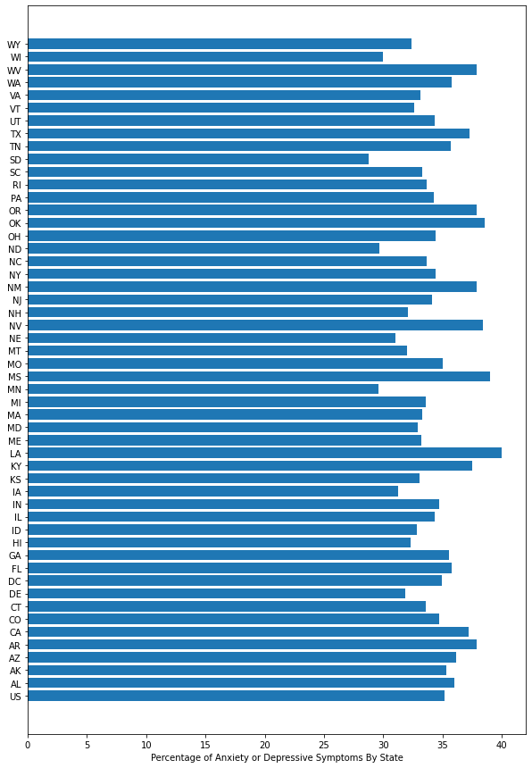

```python
state_to_initials = {"Alabama": "AL","Alaska": "AK","Arizona": "AZ","Arkansas": "AR","California": "CA","Colorado": "CO","Connecticut": "CT","Delaware": "DE","Florida": "FL","Georgia": "GA","Hawaii": "HI","Idaho": "ID","Illinois": "IL","Indiana": "IN","Iowa": "IA","Kansas": "KS","Kentucky": "KY","Louisiana": "LA","Maine": "ME","Maryland": "MD","Massachusetts": "MA","Michigan": "MI","Minnesota": "MN","Mississippi": "MS","Missouri": "MO","Montana": "MT","Nebraska": "NE","Nevada": "NV","New Hampshire": "NH","New Jersey": "NJ","New Mexico": "NM","New York": "NY","North Carolina": "NC","North Dakota": "ND","Ohio": "OH","Oklahoma": "OK","Oregon": "OR","Pennsylvania": "PA","Rhode Island": "RI","South Carolina": "SC","South Dakota": "SD","Tennessee": "TN", "Texas": "TX", "Utah": "UT", "Vermont": "VT", "Virginia": "VA", "Washington": "WA", "West Virginia": "WV", "Wisconsin": "WI", "Wyoming": "WY", "District of Columbia": "DC", "United States": "US",}
temp_subgroup_arr = list(subgroup_dict["By State"])
temp_stat_arr = []
for subgroup in temp_subgroup_arr:
    temp_stat_arr.append(get_statistic_of_subgroup(df_either, subgroup, np.mean))
temp_subgroup_arr = list(map(state_to_initials.get, temp_subgroup_arr))
plt.figure(figsize=(10, 15))
plt.barh(temp_subgroup_arr, temp_stat_arr)
plt.xlabel("Percentage of Anxiety or Depressive Symptoms " + group)
plt.show()
```

This is a little better, but not by much. At the very least, we can see that Louisiana is the state that has the greatest average percentage of symptomatic individuals. The United States as a whole is also around average compared to all of its states, which makes sense. Still, this is difficult to take in all at once. A bar chart alone wouldn't be sufficient for geographical trends.

As such, we can visualize this data even better with maps!

## Data Visualization By State

To visualize our data using maps, we'll be using the [folium](https://python-visualization.github.io/folium/) library. Specifically, we'll be aiming to show how each state's symptomatic averages stand across the United States. As such, we'll also be leaving out the National Estimate from this visualization.

```python
url = "https://raw.githubusercontent.com/python-visualization/folium/master/examples/data"
state_geo = f"{url}/us-states.json" # Necessary to properly show the U.S. states!
state_subgroup_arr = list(subgroup_dict["By State"])
state_subgroup_arr.remove("United States")
def create_df_choropleth(df):
    df_choropleth = df.copy(deep=True) # Temporary, dummy DataFrame just for this one use.
    df_choropleth["Subgroup"] = df["Subgroup"].apply(lambda x: x if x in state_subgroup_arr else np.nan)
    df_choropleth = df_choropleth.dropna()
    # Choropleth maps take U.S. states via their abbreviations, so we need to reduce each full state name to its abbreviation!
    df_choropleth["Subgroup"] = df_choropleth["Subgroup"].apply(lambda x: state_to_initials.get(x))
    return df_choropleth
df_choropleth = create_df_choropleth(df_either)
```

```python
def create_map_from_df(df, color, legend):
    m = folium.Map(location=[48, -102], zoom_start=3)
    folium.Choropleth(
        geo_data=state_geo,
        name="choropleth",
        data=df,
        columns=["Subgroup", "Value"],
        key_on="feature.id",
        fill_color=color,
        fill_opacity=0.8,
        line_opacity=0.6,
        legend_name=legend,
    ).add_to(m)
    folium.LayerControl().add_to(m)
    display(m)

create_map_from_df(df_choropleth, "BuGn", "Anxiety or Depressive Symptoms on Average (%)")
```

Make this Notebook Trusted to load map: File -> Trust Notebook

[interactive chart not shown]

Now we have a *much* more clear visualization of how individual states compare to one another!

States in the South tend to show more symptoms of anxiety or depression, along with some West Coast states. Individuals in Midwestern states show far fewer symptoms than that in other regions. Although we cannot establish a reason as to why such an apparent trend exists, any action that would be taken as a result of this analysis should include this geographical approach to comparing symptoms of mental health disorders.

However, what we *can* still do is analyze different indicators. Remember how we filtered our current DataFrame to only analyze symptoms of anxiety or depression? We can also analyze only one or the other instead!

```python
# Performing similar steps as what we did previously to extract only one indicator...
df_anxiety = df_all_indicators.copy(deep=True)
df_depression = df_all_indicators.copy(deep=True)
df_anxiety = df_anxiety[(df_anxiety["Indicator"] == 'Symptoms of Anxiety Disorder')]
df_depression = df_depression[(df_depression["Indicator"] == 'Symptoms of Depressive Disorder')]
df_anxiety = df_anxiety.dropna()
df_depression = df_depression.dropna()
```

```python
df_choropleth = create_df_choropleth(df_anxiety)
create_map_from_df(df_choropleth, "YlOrBr", "Anxiety Symptoms on Average (%)")
df_choropleth = create_df_choropleth(df_depression)
create_map_from_df(df_choropleth, "PuRd", "Depression Symptoms on Average (%)")
```

Make this Notebook Trusted to load map: File -> Trust Notebook

[interactive chart not shown]

Make this Notebook Trusted to load map: File -> Trust Notebook

[interactive chart not shown]

Even after analyzing individual symptoms, we still witness similar trends from the first map. Southern states take a higher prevalence of anxiety and depressive symptoms on individual scales, but one notable difference involves the West Coast. California—which was once one of the highest states that showed symptoms—does not stand among the top states in these two maps.

However, aside from this difference, the maps are relatively similar across all indicators. This may indicate that some states are simply predisposed to mental health disorders, regardless of the actual type. Maybe they have fewer resources to deal with mental health disorders [Comorbidity](https://www.psychiatrictimes.com/view/understanding-comorbid-depression-and-anxiety) might also be at play here, but regardless, sufficient conclusions are outside the scope of this analysis.

## Analyzing Symptoms over Time

Having analyzed several trends of groups and subgroups and visualized them, we have conveniently left out how much time plays a role in mental health disorder symptoms. Do we see a general increase, decrease, or some other trend in average symptom prevalence over time? Let's find out!

First off, let's just get a general sense of how time influences symptom prevalence. For now, we will not look at any specific subgroups—instead, we will plot our line graph solely on the values of the average of each unique `Time Period End Date`.

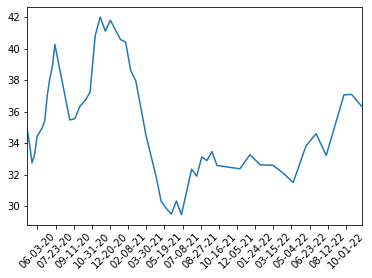

```python
def get_statistic_of_period(df, period, function):
    arr = []
    for idx,row in df[df['Time Period End Date']==period].iterrows():
        arr.append(row['Value'])
    return function(arr)
def plot_average_values_over_time(datetime_period_arr, period_avg_values_arr):
    plt.plot(datetime_period_arr, period_avg_values_arr)
    plt.gca().xaxis.set_major_formatter(mdates.DateFormatter('%m-%d-%y'))
    plt.gca().xaxis.set_major_locator(mdates.DayLocator(interval=50))
    plt.gca().xaxis.set_tick_params(rotation=45)
    plt.gca().set_xbound(datetime_period_arr[0], datetime_period_arr[len(datetime_period_arr)-1])
    plt.show()

period_arr = df_either['Time Period End Date'].unique()
period_avg_values_arr = []
for period in period_arr:
    period_avg_values_arr.append(get_statistic_of_period(df_either, period, np.mean))
# We'll use datetimes instead of strings for our x-axis!
string_to_datetime = lambda x: dt.datetime.strptime(x, '%m/%d/%Y')
datetime_period_arr = list(map(string_to_datetime, period_arr))
plot_average_values_over_time(datetime_period_arr, period_avg_values_arr)
```

The sharp decline in anxiety and depressive symptoms at around February 8, 2021, immediately stands out in this line plot. Not only does the decline last until around May 19, 2021, but from then on, the number of symptoms shown never reaches its past heights again.

This plot might be somewhat blown out of proportion, considering that this graph only shows at most around a 12% decline on average across all surveys, but the fact remains that some factors between February 2021 and May 2021 contributed to a sharp decline lasting several months.

So what *is* this factor? Could be a product of one indicator (anxiety or depression) weighed more heavily? Let's try and find out!

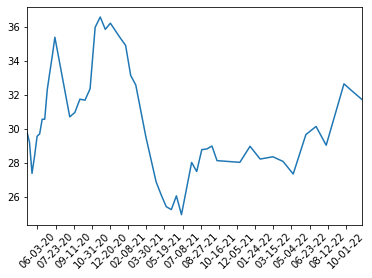

```python
period_arr = df_anxiety['Time Period End Date'].unique()
period_avg_values_arr = []
for period in period_arr:
    period_avg_values_arr.append(get_statistic_of_period(df_anxiety, period, np.mean))
datetime_period_arr = list(map(string_to_datetime, period_arr))
plot_average_values_over_time(datetime_period_arr, period_avg_values_arr)
```

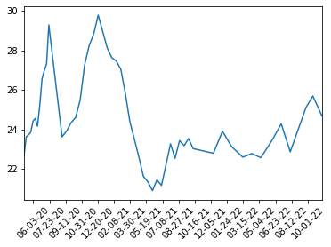

```python
period_arr = df_depression['Time Period End Date'].unique()
period_avg_values_arr = []
for period in period_arr:
    period_avg_values_arr.append(get_statistic_of_period(df_depression, period, np.mean))
datetime_period_arr = list(map(string_to_datetime, period_arr))
plot_average_values_over_time(datetime_period_arr, period_avg_values_arr)
```

Well, even when weighing anxiety and depression alone, they share the sharp decline. Now would be a good time to investigate our subgroups in relation to time.

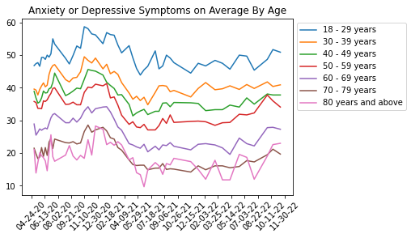

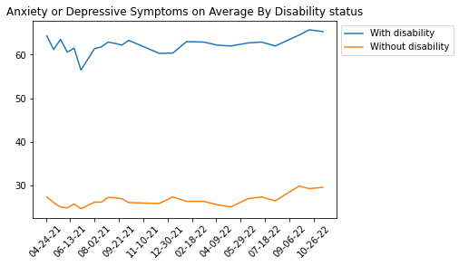

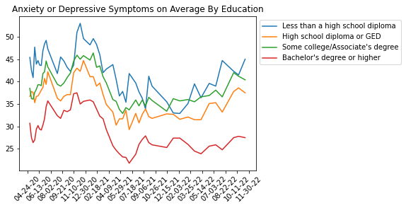

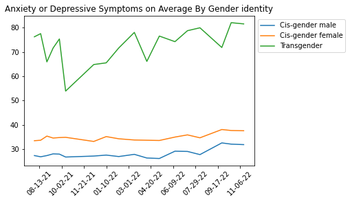

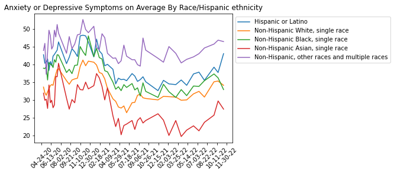

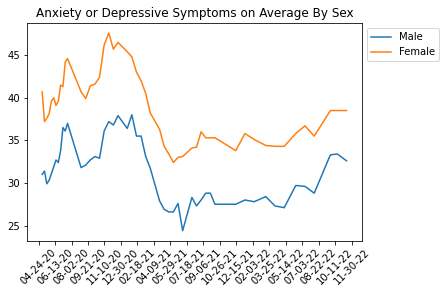

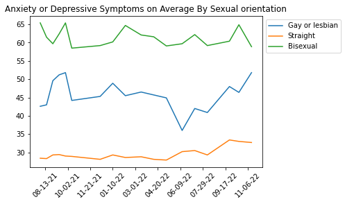

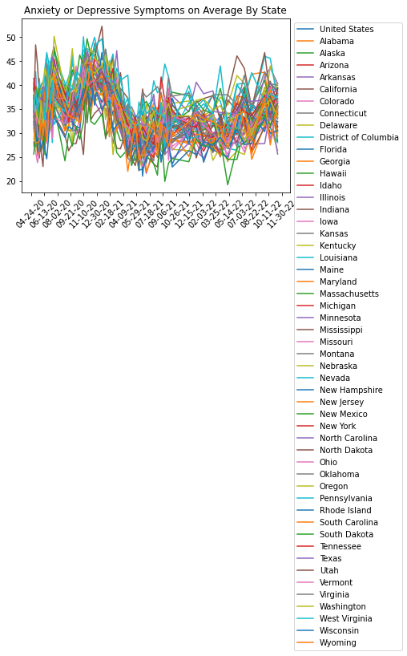

```python
def get_statistic_of_subgroup_and_period(df, subgroup, period, function):
    arr = []
    for idx,row in df[(df['Subgroup']==subgroup) & (df['Time Period End Date']==period)].iterrows():
        arr.append(row['Value'])
    return function(arr)

for group in subgroup_dict:
    subgroup_arr = list(subgroup_dict[group])
    for subgroup in subgroup_arr:
        stat_arr = []
        for period in period_arr:
            stat_arr.append(get_statistic_of_subgroup_and_period(df_either, subgroup, period, np.mean))
        plt.plot(datetime_period_arr, stat_arr, label=subgroup)
        plt.gca().xaxis.set_major_formatter(mdates.DateFormatter('%m-%d-%y'))
        plt.gca().xaxis.set_major_locator(mdates.DayLocator(interval=50))
        plt.gca().xaxis.set_tick_params(rotation=45)
    plt.title("Anxiety or Depressive Symptoms on Average " + group)
    plt.legend(bbox_to_anchor=(1,1), loc="upper left")
    plt.show()
```

On a general scale from our subgroups, our findings from our earlier bar graph visualizations hold up across time as well. There remains a correlation between age and symptoms, disabled persons are more likely to be symptomatic than those who are not, and so on.

```python
# We need to use direct latitude and longitude values, so I pull values from a site that had already curated them per state!
getStuff = requests.get("https://inkplant.com/code/state-latitudes-longitudes")
soup = BeautifulSoup(getStuff.text, 'html.parser')
soup = soup.prettify()
df_latlon = pd.read_html(soup)
df_latlon = df_latlon[0]
df_latlon.head()
```

|  | State | Latitude | Longitude |
| --- | --- | --- | --- |
| 0 | Alabama | 32.806671 | -86.791130 |
| 1 | Alaska | 61.370716 | -152.404419 |
| 2 | Arizona | 33.729759 | -111.431221 |
| 3 | Arkansas | 34.969704 | -92.373123 |
| 4 | California | 36.116203 | -119.681564 |

```python
# Organizing our data for our HeatMapOverTime, in which we'll need...
    # - A list of 51 elements (time period list), consisting of:
        # - A list of 51 elements (state list), consisting of:
            # - Latitude
            # - Longitude
            # - Value
    # - A list of 51 elements, being our Time Period End Dates.
latlon_arr = []
for period in period_arr:
    outer_arr = []
    for i in range(len(state_subgroup_arr)):
        inner_arr = []
        row = df_latlon.iloc[i] # Everything being organized for us beforehand makes our lives a little easier!
        inner_arr.append(row["Latitude"])
        inner_arr.append(row["Longitude"])
        value = (get_statistic_of_subgroup_and_period(df_either, state_subgroup_arr[i], period, (lambda x: x) ) )
        inner_arr.append(value[0]) # There should only be one element as a result of this, anyway!
        outer_arr.append(inner_arr) # By this step, we've completed gaining a state's data for a certain period.
    latlon_arr.append(outer_arr) # By this step, we've completed gaining all data for a certain time period for all states.
```

```python
# Reorganizing our time periods to a "YYYY-MM-DD" format instead of "MM/DD/YYYY".
formatted_time_period_arr = []
for i in period_arr:
    x = re.findall("\d{2,4}", i)
    formatted_time_period_arr.append(x[2] + "-" + x[0] + "-" + x[1])
m = folium.Map(location=[48, -102], zoom_start=3)
hm = HeatMapWithTime(data=latlon_arr,index=formatted_time_period_arr,radius=30,auto_play=True,use_local_extrema=True)
hm.add_to(m)
display(m)
```

Make this Notebook Trusted to load map: File -> Trust Notebook

[interactive chart not shown]

Each state appears to fluctuate on its own, but we do see some familiar clusters as shown in our previous map. The Midwest generally shows less symptoms even over time, while regions such as the East Coast and South tend to fluctuate. After around February 2021, we do witness some decline in symptoms overall, but each state tends to operate individually in their trends. Although this map is an improvement over our cluttered line plot from earlier, we do not gain much insight into determining what could be the root of the sudden drop in symptom prevalence.

# Conclusions

In our attempts to understand how prevalent anxiety and depressive symptoms are in the United States, we have seen notable and distinct trends, but without much explanation as to how they came to be. At the very least, however, what we do know can lead to helpful policymaking or actions for the future. In particular, we would want to investigate further into why certain subgroups show much higher rates of symptoms than others (disabled people, transgender people, bisexual people, and so on). This would be instrumental in providing them more resources to cope with their potential disorders.

One notable aspect that has not been discussed up until now involves the slow uptick of symptom prevalence around July 2021. We *do* have an explanation for this, as explained by the [CDC's Household Pulse Survey site](https://www.cdc.gov/nchs/covid19/pulse/mental-health.htm):

> Beginning in Phase 3.2 (July 21, 2021) of data collection and reporting, the question reference period changed from the ‘last 7 days’ to the ‘last two weeks’, as typical for this scale.

By extending the reach in which symptoms could appear, it is natural to see how symptom prevalence would increase over time. However, this explanation still leaves us unsure as to what could have caused the sharp decline from early 2021—a trend that persists even among subgroups.

As far as the geographical aspect of this study, we witnessed some clustering and some regions that show more symptoms than others. Unfortunately, because our dataset only provides individual state information for subgroups for only the `By State` group, we cannot test the interactions between other subgroups.

Despite our shortcomings in analyzing this dataset, we still have a decent footing in how to proceed if we would want to investigate this topic further.